# Shashi_proj5_Credit_Card_Customer_Segmentation

### AllLife Credit Card Customer Segmentation

### Background:

AllLife Bank wants to focus on its credit card customer base in the next financial year. They have been advised by their marketing research team, that the penetration in the market can be improved. Based on this input, the Marketing team proposes to run personalised campaigns to target new customers as well as upsell to existing customers. Another insight from the market research was that the customers perceive the support services of the back poorly. Based on this, the Operations team wants to upgrade the service delivery model, to ensure that customers queries are resolved faster. Head of Marketing and Head of Delivery both decide to reach out to the Data Science team for help.

### Objective:

To identify different segments in the existing customer based on their spending patterns as well as past interaction with the bank.

### Key Questions:

1. How many different segments of customers are there?
2. How are these segments different from each other?
3. What are your recommendations to the bank on how to better market to and service these customers?

### Data Description:

- Data is of various customers of a bank with their credit limit, the total number of credit cards the customer has, and different channels through which customer has contacted the bank for any queries, different channels include visiting the bank, online and through a call centre.

### Steps to follow:

1. Perform univariate analysis on the data to better understand the variables at your disposal and to get an idea about the no of clusters. Perform EDA, create visualizations to explore data. (10 marks)
2. Properly comment on the codes, provide explanations of the steps taken in the notebook and conclude your insights from the graphs. (5 marks)
3. Execute K-means clustering use elbow plot and analyse clusters using boxplot (10 marks)
4. Execute hierarchical clustering (with different linkages) with the help of dendrogram and cophenetic coeff. Analyse clusters formed using boxplot (15 marks)
5. Calculate average silhouette score for both methods. (5 marks)
6. Compare K-means clusters with Hierarchical clusters. (5 marks)
7. Analysis the clusters formed, tell us how is one cluster different from another and answer all the key questions. (10 marks)

Import all necessary modules and load the data

```python
%matplotlib inline
import numpy as np
import pandas as pd
import matplotlib.pyplot as plt
import seaborn as sns
import warnings

from scipy.stats import zscore

from sklearn.model_selection  import train_test_split
from sklearn.cluster import KMeans
from sklearn.cluster import AgglomerativeClustering
from sklearn.metrics import silhouette_score

warnings.filterwarnings("ignore")  # Not always recommended, but just so our notebook looks clean for this activity
sns.set_style('darkgrid')
```

Load and review data

```python
cData = pd.read_csv("Credit_Card_Customer_Data.csv");
cData.head(20) # Looks like we can drop the SI_No coloumn and Customer Key Coloumn.
```

|  | Sl_No | Customer Key | Avg_Credit_Limit | Total_Credit_Cards | Total_visits_bank | Total_visits_online | Total_calls_made |
| --- | --- | --- | --- | --- | --- | --- | --- |
| 0 | 1 | 87073 | 100000 | 2 | 1 | 1 | 0 |
| 1 | 2 | 38414 | 50000 | 3 | 0 | 10 | 9 |
| 2 | 3 | 17341 | 50000 | 7 | 1 | 3 | 4 |
| 3 | 4 | 40496 | 30000 | 5 | 1 | 1 | 4 |
| 4 | 5 | 47437 | 100000 | 6 | 0 | 12 | 3 |
| 5 | 6 | 58634 | 20000 | 3 | 0 | 1 | 8 |
| 6 | 7 | 48370 | 100000 | 5 | 0 | 11 | 2 |
| 7 | 8 | 37376 | 15000 | 3 | 0 | 1 | 1 |
| 8 | 9 | 82490 | 5000 | 2 | 0 | 2 | 2 |
| 9 | 10 | 44770 | 3000 | 4 | 0 | 1 | 7 |
| 10 | 11 | 52741 | 10000 | 4 | 0 | 5 | 5 |
| 11 | 12 | 52326 | 13000 | 3 | 0 | 2 | 7 |
| 12 | 13 | 92503 | 11000 | 1 | 2 | 5 | 9 |
| 13 | 14 | 25084 | 9000 | 1 | 1 | 5 | 6 |
| 14 | 15 | 68517 | 6000 | 2 | 2 | 4 | 6 |
| 15 | 16 | 55196 | 8000 | 2 | 0 | 5 | 7 |
| 16 | 17 | 62617 | 15000 | 2 | 1 | 2 | 4 |
| 17 | 18 | 96463 | 8000 | 2 | 0 | 3 | 4 |
| 18 | 19 | 39137 | 11000 | 2 | 2 | 2 | 7 |
| 19 | 20 | 14309 | 19000 | 4 | 1 | 5 | 8 |

Print the datatypes of each column and the shape of the dataset

```python
cData.shape
```

```
(660, 7)
```

```python
cData.dtypes
```

```
Sl_No                  int64
Customer Key           int64
Avg_Credit_Limit       int64
Total_Credit_Cards     int64
Total_visits_bank      int64
Total_visits_online    int64
Total_calls_made       int64
dtype: object
```

```python
cData.dtypes.value_counts()
```

```
int64    7
dtype: int64
```

```python
cData.columns
```

```
Index(['Sl_No', 'Customer Key', 'Avg_Credit_Limit', 'Total_Credit_Cards',
       'Total_visits_bank', 'Total_visits_online', 'Total_calls_made'],
      dtype='object')
```

Range

```python
print(cData.max() - cData.min())
```

```
Sl_No                     659
Customer Key            88578
Avg_Credit_Limit       197000
Total_Credit_Cards          9
Total_visits_bank           5
Total_visits_online        15
Total_calls_made           10
dtype: int64
```

Print the descriptive statistics (min,max,count,25th percentile,50th percentile, 75th percentile values)

```python
cData.describe().transpose()
```

|  | count | mean | std | min | 25% | 50% | 75% | max |
| --- | --- | --- | --- | --- | --- | --- | --- | --- |
| Sl_No | 660.0 | 330.500000 | 190.669872 | 1.0 | 165.75 | 330.5 | 495.25 | 660.0 |
| Customer Key | 660.0 | 55141.443939 | 25627.772200 | 11265.0 | 33825.25 | 53874.5 | 77202.50 | 99843.0 |
| Avg_Credit_Limit | 660.0 | 34574.242424 | 37625.487804 | 3000.0 | 10000.00 | 18000.0 | 48000.00 | 200000.0 |
| Total_Credit_Cards | 660.0 | 4.706061 | 2.167835 | 1.0 | 3.00 | 5.0 | 6.00 | 10.0 |
| Total_visits_bank | 660.0 | 2.403030 | 1.631813 | 0.0 | 1.00 | 2.0 | 4.00 | 5.0 |
| Total_visits_online | 660.0 | 2.606061 | 2.935724 | 0.0 | 1.00 | 2.0 | 4.00 | 15.0 |
| Total_calls_made | 660.0 | 3.583333 | 2.865317 | 0.0 | 1.00 | 3.0 | 5.00 | 10.0 |

IQR -

```python
Q1 = cData.quantile(0.25)
Q3 = cData.quantile(0.75)
IQR = Q3 - Q1
print(IQR)
```

```
Sl_No                    329.50
Customer Key           43377.25
Avg_Credit_Limit       38000.00
Total_Credit_Cards         3.00
Total_visits_bank          3.00
Total_visits_online        3.00
Total_calls_made           4.00
dtype: float64
```

Median

```python
cData.median()
```

```
Sl_No                    330.5
Customer Key           53874.5
Avg_Credit_Limit       18000.0
Total_Credit_Cards         5.0
Total_visits_bank          2.0
Total_visits_online        2.0
Total_calls_made           3.0
dtype: float64
```

```python
cData.skew()   # to measure the skewness of every attribute
```

```
Sl_No                  0.000000
Customer Key           0.051462
Avg_Credit_Limit       2.202396
Total_Credit_Cards     0.144879
Total_visits_bank      0.141896
Total_visits_online    2.225607
Total_calls_made       0.658905
dtype: float64
```

Find the number zeros in the column and the missing values

```python
(cData == 0).sum() # We have coloums which have zero values Total_visits_bank,Total_visits_online and Total_calls_made
```

```
Sl_No                    0
Customer Key             0
Avg_Credit_Limit         0
Total_Credit_Cards       0
Total_visits_bank      100
Total_visits_online    144
Total_calls_made        97
dtype: int64
```

```python
cData.isna().sum() # We don't have any missing values
```

```
Sl_No                  0
Customer Key           0
Avg_Credit_Limit       0
Total_Credit_Cards     0
Total_visits_bank      0
Total_visits_online    0
Total_calls_made       0
dtype: int64
```

Perform univariate analysis on the data to better understand the variables at your disposal and to get an idea about the no of clusters. Perform EDA, create visualizations to explore data.

```python
Sl_No = cData['Sl_No']
```

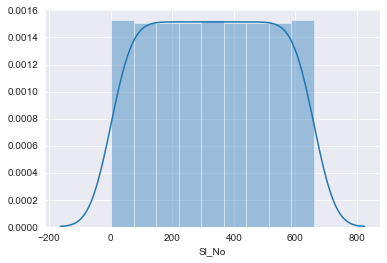

```python
sns.distplot(Sl_No) # We can drop this coloumn.
```

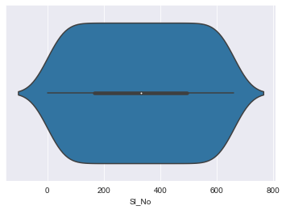

```python
sns.violinplot(Sl_No) # We can drop this coloumn. This is nice and uniform distribition. We can't get any value out of this.
```

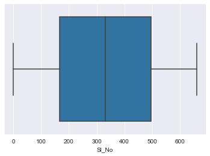

```python
sns.boxplot(Sl_No)
plt.show() #This is just Customer Serial Number. Looks like we can drop this coloum.
```

```
Mean:  330.5
Median:  330.5
Mode:  1
Skew:  0.0
```

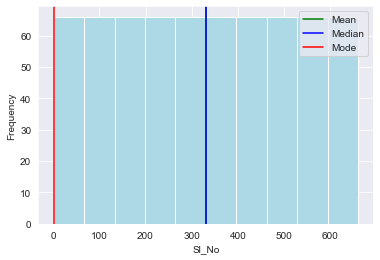

```python
mean=Sl_No.mean()
median=Sl_No.median()
mode=Sl_No.mode()
skew=Sl_No.skew()

print('Mean: ',mean,'\nMedian: ',median,'\nMode: ',mode[0], '\nSkew: ',skew)

plt.hist(Sl_No,color='lightblue') #Plot the histogram

plt.axvline(mean,color='green',label='Mean')
plt.axvline(median,color='blue',label='Median')
plt.axvline(mode[0],color='red',label='Mode')
#plt.axvline(mode[1],color='red',label='Mode2')

plt.xlabel('Sl_No')   # label the x-axis
plt.ylabel('Frequency')   # label the y-axis
plt.legend()              # Plot the legend
plt.show()
```

```python
Sl_No.value_counts()
```

```
660    1
226    1
224    1
223    1
222    1
      ..
440    1
439    1
438    1
437    1
1      1
Name: Sl_No, Length: 660, dtype: int64
```

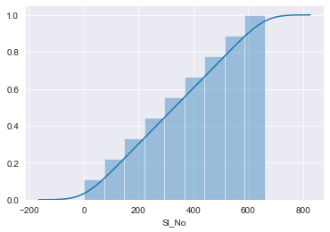

```python
# We can drop this coloumn.
sns.distplot(Sl_No, hist_kws=dict(cumulative=True), kde_kws=dict(cumulative=True))
```

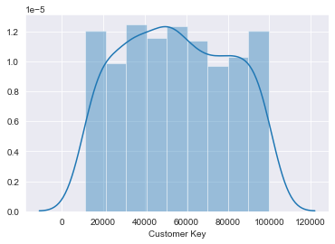

```python
Customer_Key = cData['Customer Key']
sns.distplot(Customer_Key)
# Maybe we can drop this coloumn. But we can see two clusters from the KDE curve below.
```

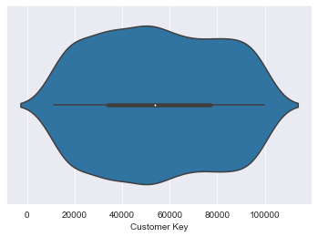

```python
sns.violinplot(Customer_Key)
```

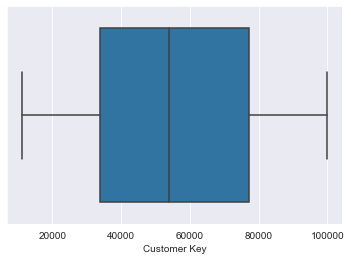

```python
sns.boxplot(Customer_Key)
plt.show()
```

```
Mean:  55141.44393939394
Median:  53874.5
Mode:  37252
Skew:  0.051461990601768696
```

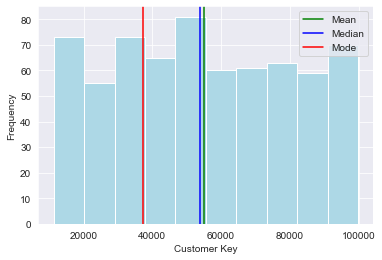

```python
mean=Customer_Key.mean()
median=Customer_Key.median()
mode=Customer_Key.mode()
skew=Customer_Key.skew()

print('Mean: ',mean,'\nMedian: ',median,'\nMode: ',mode[0], '\nSkew: ',skew)

plt.hist(Customer_Key,color='lightblue') #Plot the histogram

plt.axvline(mean,color='green',label='Mean')     # Draw lines on the plot for mean median and the two modes we have in GRE Score
plt.axvline(median,color='blue',label='Median')
plt.axvline(mode[0],color='red',label='Mode')
#plt.axvline(mode[1],color='red',label='Mode2')

plt.xlabel('Customer Key')   # label the x-axis
plt.ylabel('Frequency')   # label the y-axis
plt.legend()              # Plot the legend
plt.show()
```

```python
Customer_Key.value_counts() # Some of the Customer Keys are repeating. So clearly see two clusters from this
```

```
47437    2
37252    2
97935    2
96929    2
50706    2
        ..
66706    1
72339    1
69965    1
85645    1
71681    1
Name: Customer Key, Length: 655, dtype: int64
```

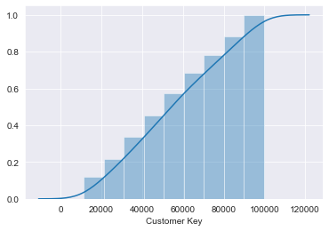

```python
sns.distplot(Customer_Key, hist_kws=dict(cumulative=True), kde_kws=dict(cumulative=True))
```

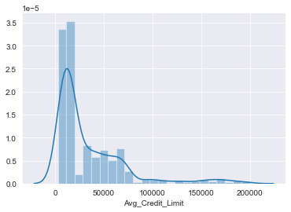

```python
Avg_Credit_Limit = cData['Avg_Credit_Limit']
sns.distplot(Avg_Credit_Limit) # So clearly see two clusters from this with a long tail. It is also positively skewed.
```

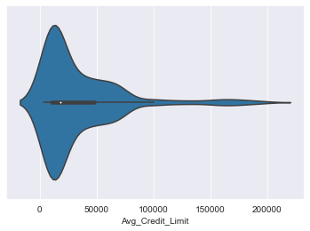

```python
sns.violinplot(Avg_Credit_Limit) #Long tail so lot of outliers. Maybe the outliers can form the third cluster.
```

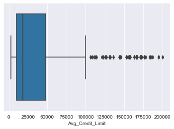

```python
sns.boxplot(Avg_Credit_Limit)
plt.show() # We can see a lot of outliers.
```

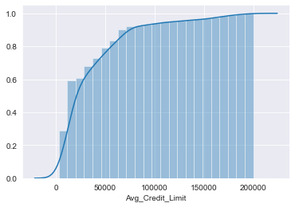

```python
sns.distplot(Avg_Credit_Limit, hist_kws=dict(cumulative=True), kde_kws=dict(cumulative=True))
```

```
Mean:  34574.242424242424
Median:  18000.0
Mode:  8000
Skew:  2.202395623436587
```

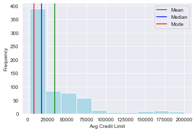

```python
mean=Avg_Credit_Limit.mean()
median=Avg_Credit_Limit.median()
mode=Avg_Credit_Limit.mode()
skew=Avg_Credit_Limit.skew()

print('Mean: ',mean,'\nMedian: ',median,'\nMode: ',mode[0], '\nSkew: ',skew)

#plt.figure(figsize=(10,5)) # set the figure size
#plt.hist(cement,bins=100,color='lightblue') #Plot the histogram
plt.hist(Avg_Credit_Limit,color='lightblue') #Plot the histogram

plt.axvline(mean,color='green',label='Mean')     # Draw lines on the plot for mean median and the two modes we have in GRE Score
plt.axvline(median,color='blue',label='Median')
plt.axvline(mode[0],color='red',label='Mode')
#plt.axvline(mode[1],color='red',label='Mode2')

plt.xlabel('Avg Credit Limit')   # label the x-axis
plt.ylabel('Frequency')   # label the y-axis
plt.legend()              # Plot the legend
plt.show()
```

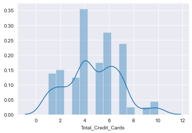

```python
Total_Credit_Cards = cData['Total_Credit_Cards']
sns.distplot(Total_Credit_Cards) #Can see three or four clusters here.
```

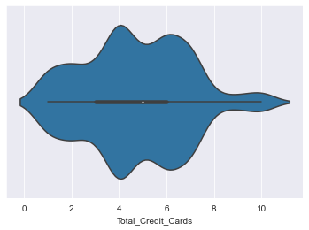

```python
sns.violinplot(Total_Credit_Cards)
```

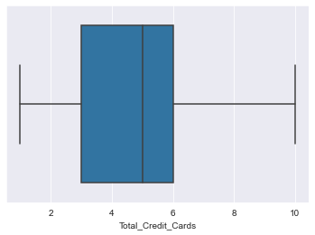

```python
sns.boxplot(Total_Credit_Cards)
plt.show()
#No outliers
```

```
Mean:  4.706060606060606
Median:  5.0
Mode:  4
Skew:  0.14487899029570606
```

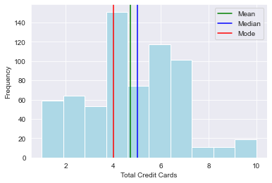

```python
mean=Total_Credit_Cards.mean()
median=Total_Credit_Cards.median()
mode=Total_Credit_Cards.mode()
skew=Total_Credit_Cards.skew()

print('Mean: ',mean,'\nMedian: ',median,'\nMode: ',mode[0], '\nSkew: ',skew)

plt.hist(Total_Credit_Cards,color='lightblue') #Plot the histogram

plt.axvline(mean,color='green',label='Mean')     # Draw lines on the plot for mean median and the two modes we have in GRE Score
plt.axvline(median,color='blue',label='Median')
plt.axvline(mode[0],color='red',label='Mode')
#plt.axvline(mode[1],color='red',label='Mode2')

plt.xlabel('Total Credit Cards')   # label the x-axis
plt.ylabel('Frequency')   # label the y-axis
plt.legend()              # Plot the legend
plt.show()
```

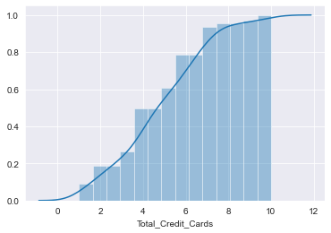

```python
sns.distplot(Total_Credit_Cards, hist_kws=dict(cumulative=True), kde_kws=dict(cumulative=True))
```

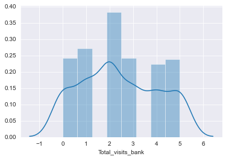

```python
#'Sl_No', 'Customer Key', 'Avg_Credit_Limit', 'Total_Credit_Cards',
#'Total_visits_bank', 'Total_visits_online', 'Total_calls_made'
Total_visits_bank = cData['Total_visits_bank']
sns.distplot(Total_visits_bank) #Can see atleast 3 clusters.
```

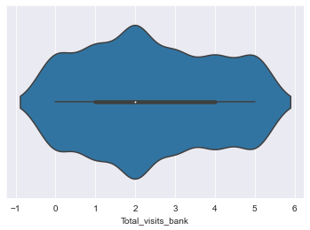

```python
sns.violinplot(Total_visits_bank)
```

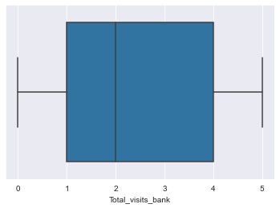

```python
sns.boxplot(Total_visits_bank)
plt.show()
#No Outliers
```

```
Mean:  2.403030303030303
Median:  2.0
Mode:  2
Skew:  0.14189601482438785
```

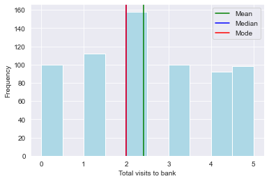

```python
mean=Total_visits_bank.mean()
median=Total_visits_bank.median()
mode=Total_visits_bank.mode()
skew=Total_visits_bank.skew()

print('Mean: ',mean,'\nMedian: ',median,'\nMode: ',mode[0], '\nSkew: ',skew)

#plt.figure(figsize=(10,5)) # set the figure size
#plt.hist(cement,bins=100,color='lightblue') #Plot the histogram
plt.hist(Total_visits_bank,color='lightblue') #Plot the histogram

plt.axvline(mean,color='green',label='Mean')     # Draw lines on the plot for mean median and the two modes we have in GRE Score
plt.axvline(median,color='blue',label='Median')
plt.axvline(mode[0],color='red',label='Mode')
#plt.axvline(mode[1],color='red',label='Mode2')

plt.xlabel('Total visits to bank')   # label the x-axis
plt.ylabel('Frequency')   # label the y-axis
plt.legend()              # Plot the legend
plt.show()
```

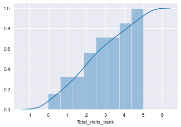

```python
sns.distplot(Total_visits_bank, hist_kws=dict(cumulative=True), kde_kws=dict(cumulative=True))
```

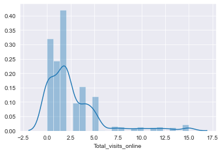

```python
Total_visits_online = cData['Total_visits_online']
sns.distplot(Total_visits_online) #long tail and we can see three clusters.
```

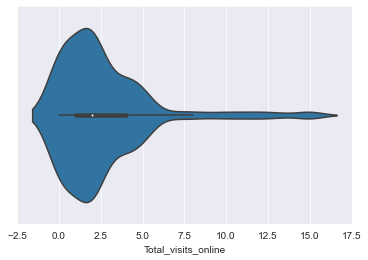

```python
sns.violinplot(Total_visits_online) #Long tail so lot of outliers. Can see a posivtive skew.
```

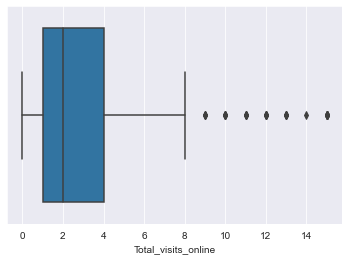

```python
sns.boxplot(Total_visits_online)
plt.show() #Lot of outliers
```

```
Mean:  2.606060606060606
Median:  2.0
Mode:  2
Skew:  2.2256067138726565
```

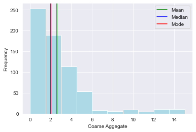

```python
mean=Total_visits_online.mean()
median=Total_visits_online.median()
mode=Total_visits_online.mode()
skew=Total_visits_online.skew()

print('Mean: ',mean,'\nMedian: ',median,'\nMode: ',mode[0], '\nSkew: ',skew)

#plt.figure(figsize=(10,5)) # set the figure size
#plt.hist(cement,bins=100,color='lightblue') #Plot the histogram
plt.hist(Total_visits_online,color='lightblue') #Plot the histogram

plt.axvline(mean,color='green',label='Mean')     # Draw lines on the plot for mean median and the two modes we have in GRE Score
plt.axvline(median,color='blue',label='Median')
plt.axvline(mode[0],color='red',label='Mode')
#plt.axvline(mode[1],color='red',label='Mode2')

plt.xlabel('Coarse Aggegate')   # label the x-axis
plt.ylabel('Frequency')   # label the y-axis
plt.legend()              # Plot the legend
plt.show()
```

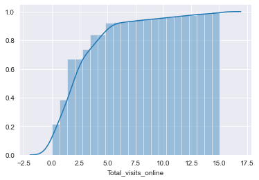

```python
sns.distplot(Total_visits_online, hist_kws=dict(cumulative=True), kde_kws=dict(cumulative=True))
```

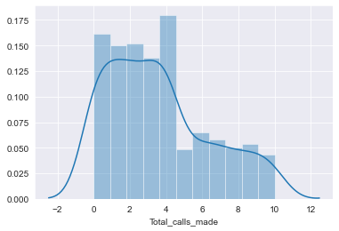

```python
Total_calls_made = cData['Total_calls_made']
sns.distplot(Total_calls_made) # Can see two clusters here.
```

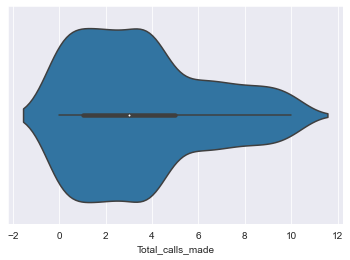

```python
sns.violinplot(Total_calls_made)
```

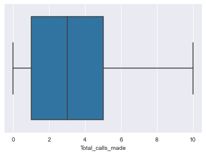

```python
sns.boxplot(Total_calls_made)
plt.show()
#No Outliers
```

```
Mean:  3.5833333333333335
Median:  3.0
Mode:  4
Skew:  0.6589053024181467
```

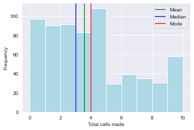

```python
mean=Total_calls_made.mean()
median=Total_calls_made.median()
mode=Total_calls_made.mode()
skew=Total_calls_made.skew()

print('Mean: ',mean,'\nMedian: ',median,'\nMode: ',mode[0], '\nSkew: ',skew)

#plt.figure(figsize=(10,5)) # set the figure size
#plt.hist(cement,bins=100,color='lightblue') #Plot the histogram
plt.hist(Total_calls_made,color='lightblue') #Plot the histogram

plt.axvline(mean,color='green',label='Mean')     # Draw lines on the plot for mean median and the two modes we have in GRE Score
plt.axvline(median,color='blue',label='Median')
plt.axvline(mode[0],color='red',label='Mode')
#plt.axvline(mode[1],color='red',label='Mode2')

plt.xlabel('Total calls made')   # label the x-axis
plt.ylabel('Frequency')   # label the y-axis
plt.legend()              # Plot the legend
plt.show()
```

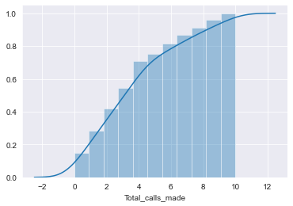

```python
sns.distplot(Total_calls_made, hist_kws=dict(cumulative=True), kde_kws=dict(cumulative=True))
```

```python
cData.corr()  # prints the correlation coefficient between every pair of attributes
```

|  | Sl_No | Customer Key | Avg_Credit_Limit | Total_Credit_Cards | Total_visits_bank | Total_visits_online | Total_calls_made |
| --- | --- | --- | --- | --- | --- | --- | --- |
| Sl_No | 1.000000 | 0.052886 | 0.677962 | 0.739329 | 0.406438 | 0.033916 | -0.684125 |
| Customer Key | 0.052886 | 1.000000 | 0.068604 | -0.010281 | -0.000560 | 0.022506 | 0.005968 |
| Avg_Credit_Limit | 0.677962 | 0.068604 | 1.000000 | 0.608860 | -0.100312 | 0.551385 | -0.414352 |
| Total_Credit_Cards | 0.739329 | -0.010281 | 0.608860 | 1.000000 | 0.315796 | 0.167758 | -0.651251 |
| Total_visits_bank | 0.406438 | -0.000560 | -0.100312 | 0.315796 | 1.000000 | -0.551861 | -0.506016 |
| Total_visits_online | 0.033916 | 0.022506 | 0.551385 | 0.167758 | -0.551861 | 1.000000 | 0.127299 |
| Total_calls_made | -0.684125 | 0.005968 | -0.414352 | -0.651251 | -0.506016 | 0.127299 | 1.000000 |

# Use correlation method to observe the relationship between different variables and state your insights.

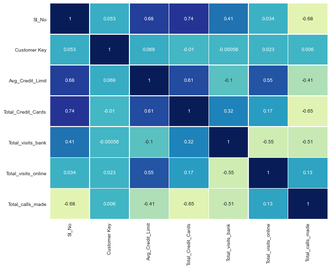

```python
plt.figure(figsize=(10,8))

sns.heatmap(cData.corr(),
            annot=True,
            linewidths=.5,
            center=0,
            cbar=False,
            cmap="YlGnBu")

plt.show() #Looks like Total_Credit_Cards and Total_visits_online are correated to Avg_Credit_Limit.
```

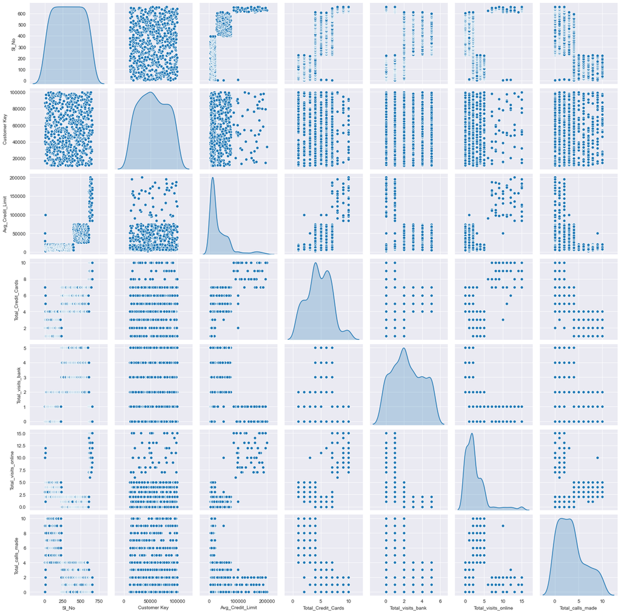

```python
sns.pairplot(cData,  diag_kind='kde')
plt.show() #We can see multiple clusters clearly for the scatter plots. We atleast see three clusters in some plots.
```

### KMeans CLustering:

```python
##Remove Sl_No since it is redundant and also Customer Key
cData.drop('Sl_No', axis=1, inplace=True)
cData.drop('Customer Key', axis=1, inplace=True)
```

```python
#Scale the data.
cData_z_Scaled = cData.apply(zscore)
```

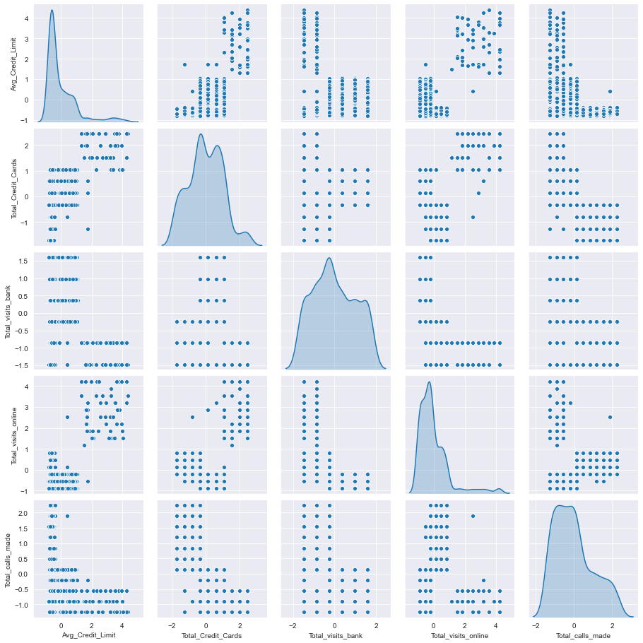

```python
sns.pairplot(cData_z_Scaled,diag_kind='kde')
```

### Elbow Method

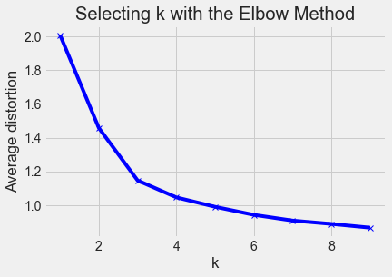

```python
#Finding optimal no. of clusters elbow method
from scipy.spatial.distance import cdist
from kneed import KneeLocator
clusters=range(1,10)
meanDistortions=[]

for k in clusters:
    model=KMeans(n_clusters=k)
    model.fit(cData_z_Scaled)
    prediction=model.predict(cData_z_Scaled)
    meanDistortions.append(sum(np.min(cdist(cData_z_Scaled, model.cluster_centers_, 'euclidean'), axis=1)) / cData_z_Scaled
                           .shape[0])


plt.style.use("fivethirtyeight")
plt.plot(clusters, meanDistortions, 'bx-')
plt.xlabel('k')
plt.ylabel('Average distortion')
plt.title('Selecting k with the Elbow Method')
```

```python
kl = KneeLocator(clusters, meanDistortions, curve="convex", direction="decreasing")
kl.elbow #Elbow value is 3.
```

```
3
```

### Silhouette Score

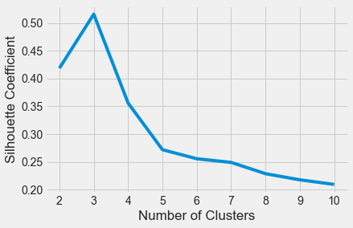

```python
#silhouette coefficient
silhouette_coefficients = []
clusters=range(2,11)

for k in clusters:
    model=KMeans(n_clusters=k)
    model.fit(cData_z_Scaled)
    prediction=model.predict(cData_z_Scaled)
    score = silhouette_score(cData_z_Scaled, prediction)
    silhouette_coefficients.append(score)

plt.style.use("fivethirtyeight")
plt.plot(clusters, silhouette_coefficients)
plt.xticks(clusters)
plt.xlabel("Number of Clusters")
plt.ylabel("Silhouette Coefficient")
plt.show() #Looks like 3 is the optiomal number of clusters.
```

```python
#  K = 3
final_model=KMeans(3)
final_model.fit(cData_z_Scaled)
prediction=final_model.predict(cData_z_Scaled)
```

### Silhouette Score

```python
silhouette_score(cData_z_Scaled, prediction)
```

```
0.5157182558881063
```

```python
#Append the prediction
cData["GROUP"] = prediction
cData_z_Scaled["GROUP"] = prediction
print("Groups Assigned : \n")
cData.head(10)
```

```
Groups Assigned :
```

|  | Avg_Credit_Limit | Total_Credit_Cards | Total_visits_bank | Total_visits_online | Total_calls_made | GROUP |
| --- | --- | --- | --- | --- | --- | --- |
| 0 | 100000 | 2 | 1 | 1 | 0 | 0 |
| 1 | 50000 | 3 | 0 | 10 | 9 | 1 |
| 2 | 50000 | 7 | 1 | 3 | 4 | 0 |
| 3 | 30000 | 5 | 1 | 1 | 4 | 0 |
| 4 | 100000 | 6 | 0 | 12 | 3 | 2 |
| 5 | 20000 | 3 | 0 | 1 | 8 | 1 |
| 6 | 100000 | 5 | 0 | 11 | 2 | 2 |
| 7 | 15000 | 3 | 0 | 1 | 1 | 1 |
| 8 | 5000 | 2 | 0 | 2 | 2 | 1 |
| 9 | 3000 | 4 | 0 | 1 | 7 | 1 |

### Analyze the distribution of the data among the groups (K = 3). One of the most informative visual tool is boxplot.

```python
cDataClust = cData.groupby(['GROUP'])
cDataClust.mean()
```

| GROUP | Avg_Credit_Limit | Total_Credit_Cards | Total_visits_bank | Total_visits_online | Total_calls_made |
| --- | --- | --- | --- | --- | --- |
| 0 | 33782.383420 | 5.515544 | 3.489637 | 0.981865 | 2.000000 |
| 1 | 12174.107143 | 2.410714 | 0.933036 | 3.553571 | 6.870536 |
| 2 | 141040.000000 | 8.740000 | 0.600000 | 10.900000 | 1.080000 |

```
array([[<matplotlib.axes._subplots.AxesSubplot object at 0x000002B530A1EA30>,
      dtype=object)
```

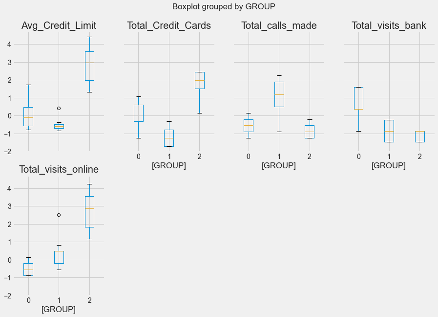

```python
cData_z_Scaled.boxplot(by='GROUP', layout = (2,4),figsize=(15,10))
```

### Hierarchical CLustering:

```python
cData.drop('GROUP', axis=1, inplace=True)
cData_z_Scaled.drop('GROUP', axis=1, inplace=True)
```

```python
from scipy.cluster.hierarchy import cophenet, dendrogram, linkage
from scipy.spatial.distance import pdist  #Pairwise distribution between data points
```

```python
# cophenet index is a measure of the correlation between the distance of points in feature space and distance on dendrogram
# closer it is to 1, the better is the clustering

Z = linkage(cData_z_Scaled, metric='euclidean', method='average')
c, coph_dists = cophenet(Z , pdist(cData_z_Scaled))

c
```

```
0.8977080867389372
```

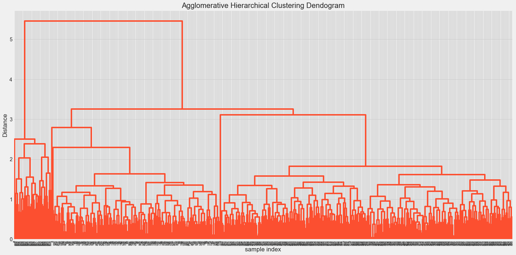

```python
plt.figure(figsize=(20, 10))
plt.title('Agglomerative Hierarchical Clustering Dendogram')
plt.xlabel('sample index')
plt.ylabel('Distance')
dendrogram(Z, leaf_rotation=90.,color_threshold = 40, leaf_font_size=8. )
plt.tight_layout()
```

```python
# cophenet index is a measure of the correlation between the distance of points in feature space and distance on dendrogram
# closer it is to 1, the better is the clustering

Z = linkage(cData_z_Scaled, metric='euclidean', method='complete')
c, coph_dists = cophenet(Z , pdist(cData_z_Scaled))

c
```

```
0.8599730607972423
```

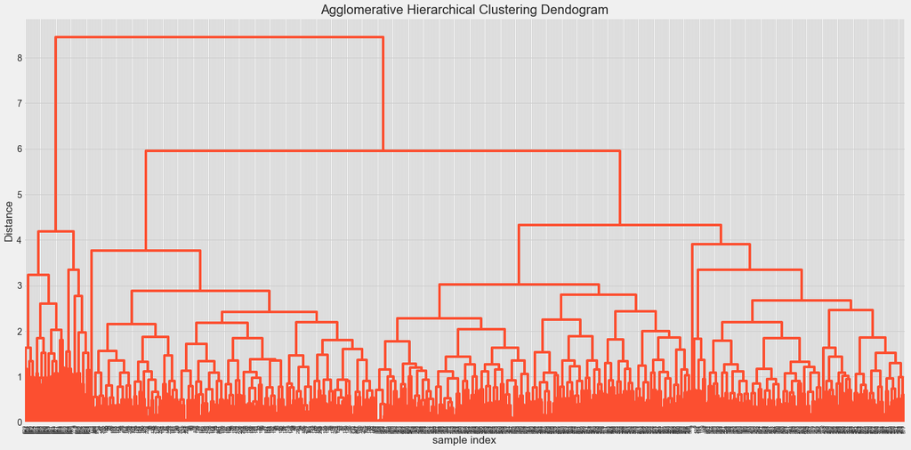

```python
plt.figure(figsize=(20, 10))
plt.title('Agglomerative Hierarchical Clustering Dendogram')
plt.xlabel('sample index')
plt.ylabel('Distance')
dendrogram(Z, leaf_rotation=90.,color_threshold=40,  leaf_font_size=8. )
plt.tight_layout()
```

```python
# cophenet index is a measure of the correlation between the distance of points in feature space and distance on dendrogram
# closer it is to 1, the better is the clustering

Z = linkage(cData_z_Scaled, metric='euclidean', method='ward')
c, coph_dists = cophenet(Z , pdist(cData_z_Scaled))

c
```

```
0.7415156284827493
```

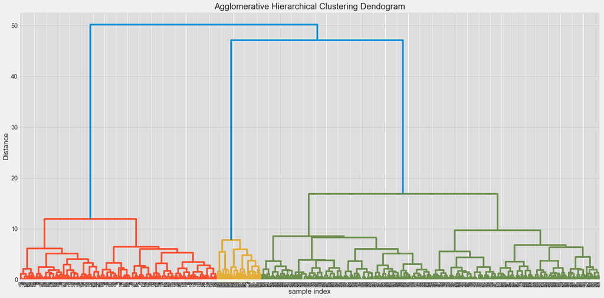

```python
plt.figure(figsize=(20, 10))
plt.title('Agglomerative Hierarchical Clustering Dendogram')
plt.xlabel('sample index')
plt.ylabel('Distance')
dendrogram(Z, leaf_rotation=90.,color_threshold = 40, leaf_font_size=8. )
plt.tight_layout()
```

```python
# We got the best Cophenetic coeff for the Average Linkage.

# Average  = 0.8977080867389372
# Complete = 0.8599730607972423
# Ward     = 0.7415156284827493
```